# Cars Segmentation using Kmeans Clustering

Divaynshu Goswami

March 11, 2019

```
                                Problem
```

We have a data of cars produced from 1970 - 1980 with different specifications. We have to form clusters to identify different segment of cars.

```
                                Solution
```

We can provide a solution by clustering/segmenting customers and indentifying their profile. We will perform non-hierarchical K-means clustering.

# install required packages

```r
#install.packages('cluster')
#install.packages('fpc')
#install.packages('NbClust')
library(cluster)
library(fpc)
library(NbClust)
```

# Extract data and check for missing values

```r
mydata <- read.csv(file.choose())

#Missing value handeling
#Replace missing values in Cubiccentimetre and Weight with mean values
mydata_na <- mydata[rowSums(is.na(mydata)) > 0,]
mydata[is.na(mydata[,3]), 3] <- mean(mydata[,3], na.rm = TRUE)
mydata[is.na(mydata[,5]), 5] <- mean(mydata[,5], na.rm = TRUE)
```

# Scale the data

```r
mydata_scld <- scale(mydata[,1:6])

#set seed

set.seed(1234)
```

# Create WSS Plot to identify optimal no. of clusters

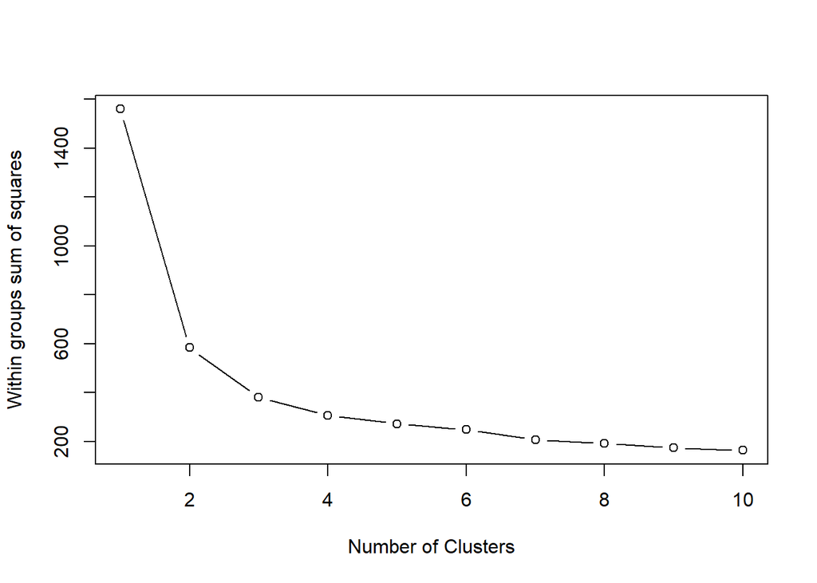

In this WSS plot we can see that WSS decreases significatntly till 3 clusters and then there is not much decrease with more no. of clusters.

## Performing non-hirarichical Kmeans clustering

```r
#nstart = 10 it will do the clustering process 10 times for each observation to check consistency of the obsevation on every iteration
clust_Km = kmeans(x=mydata_scld, centers = 3, nstart = 10)
clust_Km
```

```
## K-means clustering with 3 clusters of sizes 73, 127, 61
##
## Cluster means:
##          mpg  cylinders cubicinches         hp  weightlbs time.to.60
## 1 -1.0608484  1.3745753   1.3740407  1.3707806  1.2676983 -1.0495142
## 2  0.8008375 -0.9127996  -0.8512819 -0.7220265 -0.8384075  0.4583198
## 3 -0.3977776  0.2554354   0.1279973 -0.1372069  0.2284553  0.3017692
##
## Clustering vector:
##   [1] 1 2 1 1 2 3 1 1 3 2 2 2 1 1 3 1 2 1 2 2 2 2 3 1 2 2 2 1 3 2 2 3 2 3 2
##  [36] 3 2 2 1 3 3 1 3 3 1 2 1 2 2 3 1 2 1 2 1 1 3 2 2 1 3 2 3 2 1 3 2 2 2 1
##  [71] 3 2 2 2 2 2 3 2 2 2 1 1 1 2 2 2 3 3 2 2 2 2 1 3 2 3 1 3 1 3 1 1 2 2 2
## [106] 2 2 2 2 1 2 3 1 2 2 3 2 3 2 1 2 2 1 2 2 2 1 2 2 2 2 2 1 1 1 1 2 1 2 2
## [141] 3 2 2 2 3 2 3 2 1 1 2 2 1 3 2 3 2 2 3 3 2 1 3 3 2 3 3 2 3 2 2 3 2 2 2
## [176] 2 1 1 1 2 3 2 1 1 2 3 3 1 1 1 2 2 1 1 1 2 2 2 2 2 2 2 3 3 2 1 2 3 1 3
## [211] 3 1 2 2 3 2 2 1 3 1 3 2 1 3 1 2 1 2 3 2 1 2 2 1 3 2 1 3 2 2 1 3 1 2 1
## [246] 1 1 2 2 2 2 2 2 1 3 2 1 2 3 3 3
##
## Within cluster sum of squares by cluster:
## [1]  96.59742 207.36473  77.26018
##  (between_SS / total_SS =  75.6 %)
##
## Available components:
##
## [1] "cluster"      "centers"      "totss"        "withinss"
## [5] "tot.withinss" "betweenss"    "size"         "iter"
## [9] "ifault"
```

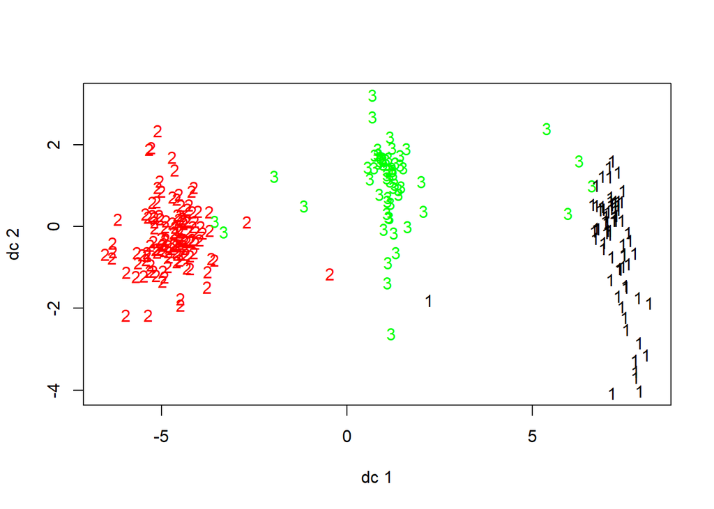

```r
########### plotting

plotcluster(mydata_scld,clust_Km$cluster)
```

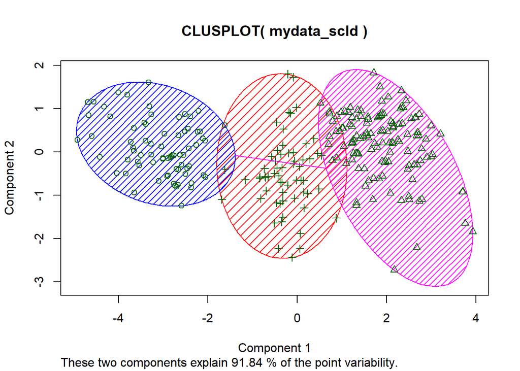

```r
mydata_nw<-data.frame(mydata,clust_Km$cluster)
clusplot(mydata_scld,clust_Km$cluster,shade = T,color = T)
```

# let’s do profiling ofdifferent segment of cars

```r
## profiling the clusters
mydata$ClustersK <- clust_Km$cluster

aggr = aggregate(mydata[,-c(8,9)],list(mydata$ClustersK),mean)
clust_km_profile <- data.frame( Cluster=aggr[,1],
                            Freq=as.vector(table(mydata$ClustersK)),
                            aggr[,-1])


#Output
print(clust_km_profile)
```

```
##   Cluster Freq      mpg cylinders cubicinches        hp weightlbs
## 1       1   73 14.84521  7.972603    350.4658 161.87671  4086.233
## 2       2  127 29.41024  4.007874    108.2677  77.11811  2297.944
## 3       3   61 20.03279  6.032787    214.8498 100.80328  3203.814
##   time.to.60     year
## 1   12.49315 1974.808
## 2   16.88189 1977.898
## 3   16.42623 1976.984
```

We can explain the above 3 clusters as following ;-

Cluster 3 - This consist of mid range cars with decent mpg of 20 miles and 6 cylinders but low pickup. These can be the middle segment multiutility vehicle.